# Task 3- Santa Barbara Sea Urchins

Deanna Mireles

10/27/2021

## Overview

This code uses data for red and purple sea urchins. We look at their sizes and the location from where they were located. The data was collected in Santa Barbara by Daniel Reed in 2020 as part of LTER.

**Data citation:** Reed, D. 2020. SBC LTER: Reef: Long-term experiment: Kelp removal: Urchin size frequency distribution ver 20. Environmental Data Initiative. https://doi.org/10.6073/pasta/5a1e9ef03aa47bd2225c0bb98a02a63b.

## Setup

Here I read in the sea urchin data using the here() function.

```r
sea_urchin <- read_csv(here("data", "urchins.csv")) %>%
  clean_names()
```

For reference, the first 6 lines of the dataset are shown below:

```r
head(sea_urchin)
```

```
## # A tibble: 6 × 6
##   date     site  treatment  size scientific_name               common_name
##   <chr>    <chr> <chr>     <dbl> <chr>                         <chr>
## 1 10/10/08 NAPL  CONTROL     2.5 Strongylocentrotus purpuratus Purple Urchin
## 2 10/10/08 NAPL  CONTROL     2.5 Strongylocentrotus purpuratus Purple Urchin
## 3 10/10/08 NAPL  CONTROL     2.5 Strongylocentrotus purpuratus Purple Urchin
## 4 10/10/08 NAPL  CONTROL     2.5 Strongylocentrotus purpuratus Purple Urchin
## 5 10/10/08 NAPL  CONTROL     2.5 Strongylocentrotus purpuratus Purple Urchin
## 6 10/10/08 NAPL  CONTROL     2.5 Strongylocentrotus purpuratus Purple Urchin
```

## Section 1- Size comparisons between purple and red sea urchins

### Data Visualization- Histogram

Here I create a histogram of the purple and red sea urchins as they correlate with their sizes.

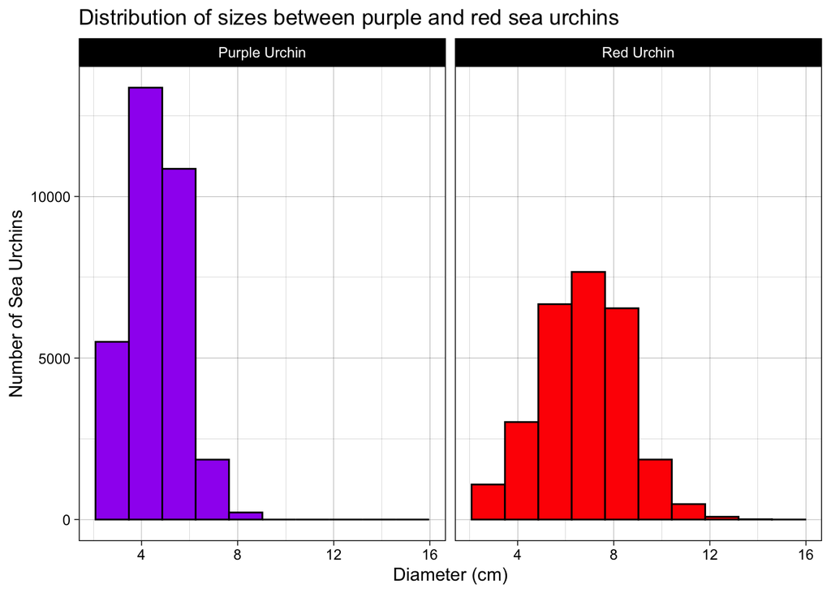

```r
ggplot(data = sea_urchin,
       aes(x = size,
           fill = common_name)) +
  scale_fill_manual(values = c("purple", "red")) +
  geom_histogram(bins = 10,
                 color = "black",
                 show.legend = FALSE) +
  facet_wrap(~ common_name) +
  theme_linedraw() +
  labs(title = "Distribution of sizes between purple and red sea urchins",
       x = "Diameter (cm)",
       y = "Number of Sea Urchins")
```

**Figure 1.** Distribution of sizes between purple and red sea urchins show that there are more smaller purple sea urchins and that red sea urchins and that red urchins tend to be larger than 4cm in diameter.

### Data Wrangling

Here I summarize the mean size, median size, standard deviation, and the sample size of both types of sea urchins and store them in their own data subset called urchins_summary.

```r
urchins_summary <- sea_urchin %>%
  group_by(scientific_name,
           common_name) %>%
  summarize(mean_size = round(mean(size), 2),
            median_size = round(median(size), 2),
            sd_size = round(sd(size), 2),
            sample_size = n()
            )
```

### Data Visualization- Summary table

Here I created a table for the summary statistics I put together above and called it “Summary table for purple and red sea urchins”.

```r
urchins_summary %>%
  kbl(caption = "Summary table for purple and red sea urchins",
      col.names= c("Scientific Name",
                   "Common Name",
                   "Mean Size (cm)",
                   "Median Size (cm)",
                   "Standard Deviation",
                   "Sample Size")) %>%
  kable_classic_2(full_width = F)
```

Summary table for purple and red sea urchins

| Scientific Name | Common Name | Mean Size (cm) | Median Size (cm) | Standard Deviation | Sample Size |
| --- | --- | --- | --- | --- | --- |
| Mesocentrotus franciscanus | Red Urchin | 6.78 | 7.0 | 1.89 | 27408 |
| Strongylocentrotus purpuratus | Purple Urchin | 4.47 | 4.5 | 1.18 | 31805 |

The histogram shows that there are more purple sea urchins that are smaller than 6 cm in diameter compared to the red sea urchins and that there are more red sea urchins that are greater than 8 cm in diameter than the purple sea urchins. The summary table confirms these observations as the mean and median sizes of red sea urchins are larger than the purple sea urchins even though more purple sea urchins were collected than red given by the sample size measurement.

## Section 2- Purple sea urchin counts by site and year

### Data Wrangling

Here I created a subset of data called purple_urchins where only purple urchins were included and the year in the data was changed to class “Date”, a new column for just the year was added, and a new column for the full names of the sites was added.

```r
purple_urchins <- sea_urchin %>%
  filter(common_name == "Purple Urchin") %>%
  mutate(date_new = ymd(date)) %>%
  mutate(year = year(date_new)) %>%
  mutate(site_full = case_when(
    site %in% c("NAPL") ~ "Naples Reef",
    site %in% c("AQUE") ~ "Arroyo Quemado Reef",
    site %in% c("CARP") ~ "Carpinteria Reef",
    site %in% c("MOHK") ~ "Mohawk Reef",
    site %in% c("IVEE") ~ "Isla Vista Reef"
  ))

# Create code for a table containing the total number of purple urchins observed by site and year.

purple_urchins_total <- purple_urchins %>%
  group_by(site_full, year) %>%
  summarize(total = n())
```

### Data Visualization- Graph

Here I made a graph of the total purple sea urchins that were recorded at each site over time.

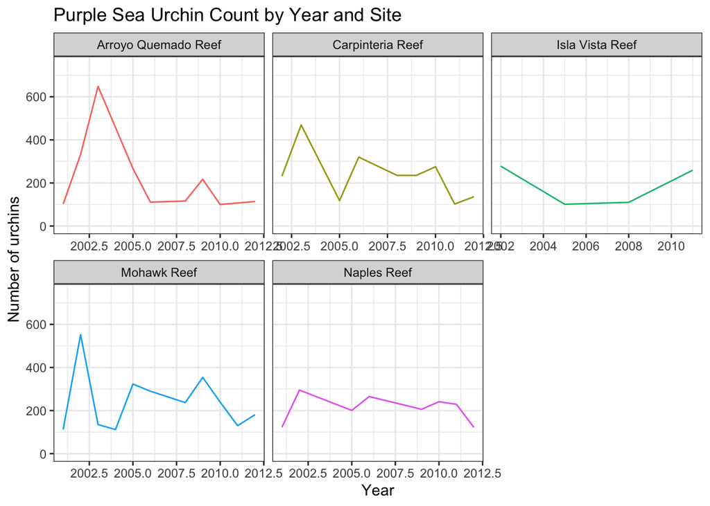

```r
ggplot(data = purple_urchins_total, aes(x = year, y = total, color = site_full)) +
  geom_line(width = 0.1, show.legend = FALSE) +
  ylim(0, 750) +
  facet_wrap(~ site_full, scales = "free_x") +
  theme_bw() +
  labs(title = "Purple Sea Urchin Count by Year and Site", x = "Year", y = "Number of urchins")
```